# Plans d’expériences

1er décembre 2020

## I. Rappels sur la régression linéaire

## Variables

Contexte et notations :

- \(X_{1},...,X_{p}\) sont des variables explicatives (descripteurs)
- \(Y\) est la variable (quantitative) à expliquer (variable d’intérêt).

Objectif : on cherche à approcher la relation entre \(Y\) et \(X_{1},...,X_{p}\) à partir d’un échantillon à \(n\) observations.

## Hypothèses

On suppose que y est la réalisation de modèle suivant :

\(y_{i} = \beta_{0} + \sum_{j=0}^{j=p} \beta_{j}x_{ij} + \epsilon_{i}, \; \forall 1\leq i\leq n\)

avec :

- \(\beta_{0},...,\beta_{p}\) nombres réels déterministes inconnus
- \(\epsilon_{1},...,\epsilon_{n}\) n variables aléatoires :
  - non corrélées
  - de moyenne nulle \(\mathbb{E}[\epsilon_{i}] = 0\)
  - de variance constante \(\mathbb{V}(\epsilon_{i}) = \sigma^{2}\).

Rq : \(X_{j}\) peut être de la forme \(X_{1}*X_{2}\) ou \(X_{1}^{2}\) par exemple

## Forme matricielle

Le modèle précédent s’écrit matriciellement :

\[\begin{bmatrix} y_{1} \\ . \\ . \\ y_{n} \end{bmatrix} = X \begin{bmatrix} \beta_{1} \\ . \\ . \\ \beta_{p} \end{bmatrix} + \begin{bmatrix} \epsilon_{1} \\ . \\ . \\ \epsilon_{p} \end{bmatrix} \]

avec \(X = \begin{bmatrix} 1 & x_{11} & .. & x_{1p} \\ .. & .. & .. & .. \\ 1 & x_{n1} & .. & x_{np} \end{bmatrix}\) ,

\(\mathbb{E}(\begin{bmatrix} \epsilon_{1} \\ . \\ . \\ \epsilon_{p} \end{bmatrix}) = 0_{n}\), et \(\mathbb{V}(\begin{bmatrix} \epsilon_{1} \\ . \\ . \\ \epsilon_{p} \end{bmatrix}) = \sigma^{2}Id_{n}\)

## Estimateur des moindres carrés

Le vecteur qui minimise la fonction

\(C(\beta) = \sum_{i=0}^{n} (y_{i} - (\beta_{0} + \beta_{1}x_{i1} + ... + \beta_{p}x_{ip})) ^ 2\)

est \(\hat{\beta} = (^{t}{X}X)^{-1}(^{t}XY)\)

On a de plus : \(\mathbb{V}(\hat{\beta}) = \sigma^{2}(^{t}{X}X)^{-1}\)

## II. Introduction aux plans d’expériences

## Exemple introductif

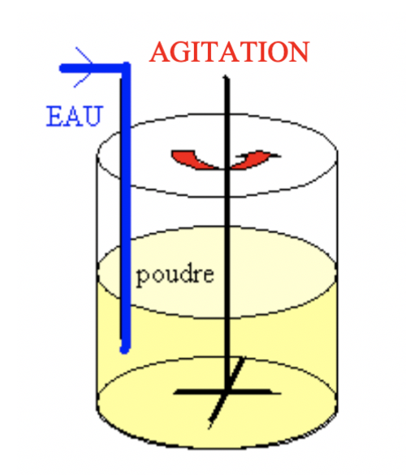

Fabrication de granules homéopatiques :

1. On humidifie et on agite une poudre au sein d’un granulateur.
2. Des agglomérats appelés granules se forment alors, sous l’effet de l’agitation, de l’humidité et de la température.
3. Un temps de repos permet de finir le grossissement des granules.
4. On s’intéresse au final à la taille moyenne des granules présents dans le granulateur

## Variables

Variables explicatives :

- taux de remplissage du granulateur (quantité de poudre introduite initialement, en %)
- débit d’eau à introduire dans le granulateur (en \(mm^{3}s^{−1}\))
- le temps de mouillage (en \(s\))
- la température de maintien (\(°C\))
- la vitesse d’agitation de la pale (en \(toursmn^{-1}\))
- le temps d’agitation (en \(s\))
- le temps de repos (en \(s\)).

Variable à expliquer : Taille moyenne des granules

## Espace des variables explicatives

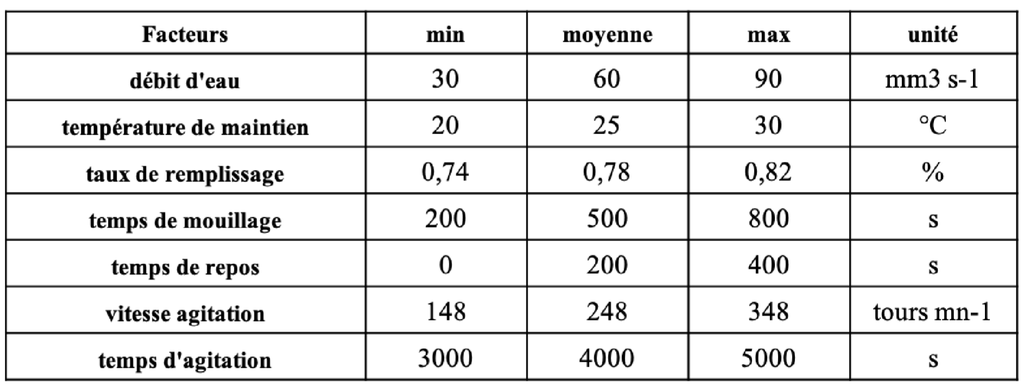

## Objectifs

Les plans d’expériences interviennent lorsque le nombre d’essai (budget, temps etc) est limité et les facteurs sont contrôlés.

Il peuvent permettre de :

- Identifier les facteurs les plus influents (Plans de criblage)
- Prédire la taille des granules sur l’ensemble du domaine (Plans de surface de réponses)

## III. Les plans d’expériences de criblage

## Cadre

On se place dans le cas d’un modèle de régression de degré 1 avec ou sans interaction. Par exemple, avec 3 variables explicatives :

\(y = \beta_{0} + \sum \beta_{i}x_{i} + \sum \beta_{ij}x_{i}x_{j} + ... + \beta_{ij..p}x_{i}x_{j}..x_{p} + \epsilon\)

Chaque variable est normalisée entre -1 et 1 :

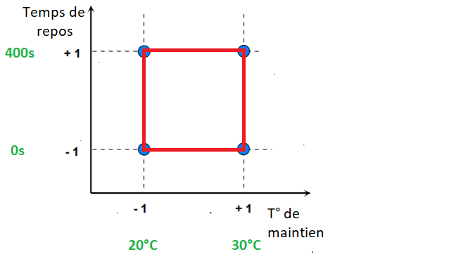

\(\; \; \; \; \; \; \; \tilde{x} = 2\frac{x-x_{min}}{x_{max} - x_{min}} -1\)

## Plan factoriel à 2 niveaux

### Principe

Les plans d’expérience factoriels permettent de traiter un nombre p quelconque de facteurs à 2 niveaux (facteur quantitatif) ou 2 modalités (facteur qualitatif).

Les expériences à réaliser le sont pour les niveaux −1 et 1 : niveaux “haut” et “bas”

### Orthogonalité

Pour évaluer l’effet d’un facteur \(X_{i}\), il faut que pour chaque niveau de ce facteur, tous les autres facteurs apparaissent autant de fois au niveau “haut” qu’au niveau “bas”, sinon leur effet biaiserait celui de \(X_{i}\). n doit donc être un multiple de 2.

Le plan d’expérience est alors dit orthogonal : \((^{t}{X}X)^{-1}\) est proportionnel à l’identité.

## Plan factoriel complet \(2^{p}\)

Il consiste à effectuer les \(n\: = \:2^{p}\) expériences possibles.  
Par exemple, pour p=3 avec 3 variables A, B et C :

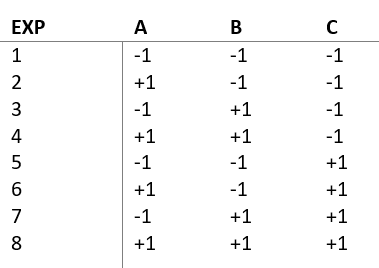

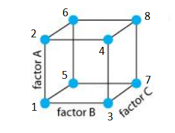

## Ajout de paramètres estimables

Le plan factoriel complet nous donne un système \(n\: = \:2^{p}\) équations.

On peut donc inclure les paramètres d’interaction, et estimer \(2^p\) paramètres :  
\(\beta_{0},\: \beta_{i}, \: \beta_{ij},\: \beta_{ij..p}\)

Dans le cas p = 3, on obtient :

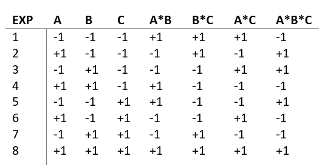

## Matrice X

La matrice X s’obtient en rajoutant une colonne de 1 : \[ X = \begin{bmatrix} +1 & -1 & -1 & -1 & +1 & +1 & +1 & -1 \\ +1 & +1 & -1 & -1 & -1 & +1 & -1 & +1 \\ +1 & -1 & +1 & -1 & -1 & -1 & +1 & +1 \\ +1 & +1 & +1 & -1 & +1 & -1 & -1 & -1 \\ +1 & -1 & -1 & +1 & +1 & -1 & -1 & +1 \\ +1 & +1 & -1 & +1 & -1 & -1 & +1 & -1 \\ +1 & -1 & +1 & +1 & -1 & +1 & -1 & -1 \\ +1 & +1 & +1 & +1 & +1 & +1 & +1 & +1 \end{bmatrix} \]

Et on a : \(\hat{\beta} = (^{t}{X}X)^{-1}(^{t}XY)\)

## Exercice :

1. Vérifier que les vecteurs de \(X\) sont orthogonaux
2. Quelle est la conséquence sur \(^{t}{X}X\) ?
3. En déduire les \(\hat{\beta_{0}}, \hat{\beta}_{A}, \:\hat{\beta}_{B}, \:\hat{\beta}_{C}, \:,\hat{\beta}_{AB}, \:\hat{\beta}_{AC}, \:\hat{\beta}_{BC}, \:\hat{\beta}_{ABC}\) pour \(Y = \begin{bmatrix} 20 \\ 25 \\ 4 \\ 16 \\ 35 \\ 63 \\ 30 \\ 76 \end{bmatrix}\)

## Calcul de \(\hat{\beta}\)

On a \(^{t}{X}X = 2^{p}Id_{n}\)

Donc \(\hat{\beta_{i}} = \frac{1}{2^{p}}(\sum_{u | x_{u} = +1} y_{u} - \sum_{v|x_{v} = -1} y_{v})\)

## Plans factoriels fractionnaires \(2^{p-q}\)

Les plans factoriels fractionnaires sont des plans factoriels qui permettent d’étudier tous les facteurs mais dont le nombre d’essais est réduit par rapport aux plans factoriels complets. Un plan factoriel fractionnaire à 2 fois moins, ou 4 fois moins ou \(2^{q}\) fois moins d’essais que le factoriel complet correspondant.

On appellera plan \(2^{p−q}\) un plan comprenant \(2^{p−q}\) unités pour p facteurs à deux niveaux

On a alors \(n = 2^{p-q}\) équations et \(2^{p}\) inconnues si l’on veut prendre en compte l’ensemble des interactions.

## Construction d’un plan \(2^{p-q}\)

On peut construire un tel plan en construisant d’abord un plan factoriel complet pour (p−q) facteurs puis on déﬁnit les q autres facteurs en fonction des (p−q) par produit uniquement.

Il va y avoir alors confusion entre certains facteurs et certaines interactions.

On appelle clef du plan l’ensemble de q relations que l’on exprime sous la forme \(1=...\)

En effet, \(F=A.B\), s’écrit \(F.A.B=1\) car \(F=A.B\:\Rightarrow\:F.F\:=\:1\:=\:F.A.B\)

La clé indique à elle-seule l’ensemble des confusions.

## Exemple : plan \(2^{5-2}\) pour 5 facteurs A,B,C,D et E

Plan complet pour A, B et C puis on ajoute D et E avec D=AB et E = AC

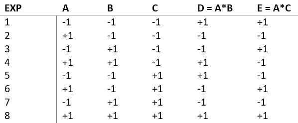

Quelle est la clef du plan ?

## Exemple : plan \(2^{5-2}\) pour 5 facteurs A,B,C,D et E

Plan complet pour A, B et C puis on ajoute D et E avec D=AB et E = AC

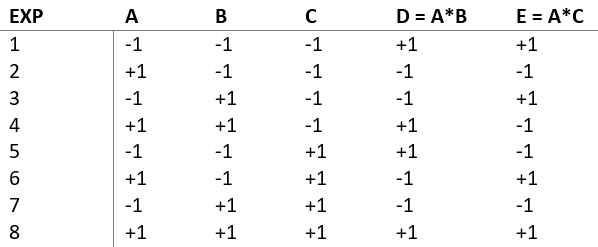

Quelle est la clef du plan ?

\(1 = ADB = ACE = BCDE\)

## Calcul des effets des facteurs

L’équation de régression linéaire à \(2^5\) inconnues (avec les interactions) se réécrit avec \(2^3\) inconnues :  
\[y=\alpha{0} + \alpha_{A}*A + \alpha_{B}*B + \alpha_{C}*C + \alpha_{D}*D + \alpha_{E}*E + \alpha_{BC}*BC + \alpha_{ABC}*ABC\] avec :

\(\alpha_{0} = \beta_{0} + \beta_{ABD} + \beta_{ACE} + \beta_{BCDE}\)  
\(\alpha_{A} = \beta_{A} + \beta_{BD} + \beta_{CE} + \beta_{ABCDE}\)  
\(\alpha_{B} = \beta_{B} + \beta_{AD} + \beta_{CDE} + \beta_{ABCE}\)  
\(\alpha_{C} = \beta_{C} + \beta_{AE} + \beta_{BDE} + \beta_{ABCD}\)  
\(\alpha_{D} = \beta_{D} + \beta_{AB} + \beta_{BCE} + \beta_{ACDE}\)  
\(\alpha_{E} = \beta_{E} + \beta_{AC} + \beta_{BCD} + \beta_{ABDE}\)  
\(\alpha_{BC} = \beta_{BC} + \beta_{DE} + \beta_{ABE} + \beta_{ACD}\)  
\(\alpha_{ABC} = \beta_{ABC} + \beta_{CD} + \beta_{BE} + \beta_{ADE}\)

Les \(\alpha_{i}\) sont appelés les contrastes du modèle.

Alias de A : \(A = BD = CE = ABCDE\)  
Les alias peuvent se déduire de la clef (et inversement)

## Hypothèses d’interprétation

Le fait que certains effets soient confondus avec d’autres complique l’interprétation des contrastes calculés. Des hypothèses vont alors être formulées :

- H1 : Interactions entre 3 facteurs ou plus sont négligeables
- H2 : Contraste nul \(\Rightarrow\) effets reliés tous nuls

Rappel : L’objectif des plans factoriels et d’étudier l’influence des variables explicatives

## Résolution

On appelle résolution du plan noté \(\rho\) l’entier :

\(\rho = inf\{nb \: de \: symboles \: des \: éléments \: de \: l'alias \: de \: 1\}\)

Dans l’exemple précédent, le plan est de résolution III :

\(1 = ADB = ACE = BCDE\)

On a ainsi, par exemple :

- Résolution III : certains eﬀets principaux sont confondus avec des interactions ”double”(produit de 2 facteurs)
- Résolution IV : un eﬀet principal ne peut être confondu avec une interaction ”double”, mais certaines interactions ”doubles” sont confondues entre elles
- Résolution V : on peut poser un modèle avec toutes les interactions ”doubles” et les eﬀets principaux sans confusion

## Remarque : Estimation de l’écart type

Dans tout ce qui précède on ne voulait estimer que les effets des facteurs \(\hat{\beta}_{i}\).

Si l’on veut estimer l’écart type \(\sigma\), cela rajoute une inconnue : \[\hat{\sigma} = \frac{1}{\sqrt{n-\tilde{p}-1}}\|Y-\hat{Y}\|\] avec \(n\) = nb d’équations (nb de lignes de X)  
\(\tilde{p} + 1\) = nb de facteurs pris en compte (nb de colonnes de X)

\(\Rightarrow\) Si on veut estimer la variance, X ne doit pas être une matrice carrée

## Conclusion partie III

Plans factoriels à 2 niveaux sont :

- Simples à construire
- Peu coûteux en essais
- Orthogonaux

Mais : Ils ne concernent que les modèles de degré 1, et ne permettent donc pas l’étudier la surface de réponse lorsque l’on suspecte une courbure

## IV : Plans de surface de réponse

## Exercice

Exercice On veut construire un plan pour 1 facteur quantitatif A appartenant à \([−1,1]\). On souhaite estimer un modèle de degré 2.

1. Combien de paramètres y-a-t-il à estimer? Cela conditionne le nombre d’essais à eﬀectuer au minimum.
2. Est-ce possible d’estimer un modèle de degré 2 avec des expériences dupliquées en −1 et en 1?
3. On choisit de réaliser 3 expériences : 1 en −1, 1 en 1, 1 en a, a ∈ \([−1,1]\). A votre avis, comment choisir a pour une estimation la plus précise possible des paramètres?

## IV.1 Les plans classiques

Présentations des quelques plans de surface de réponse classiques :

- Plan factoriel complet à 3 niveaux
- Plan composite centré
- Plan de Box Benkhen

## Le plan factoriel complet à 3 niveaux

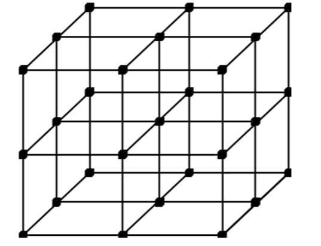

## Plan composite centré

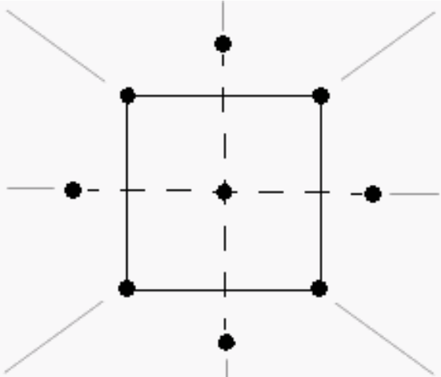

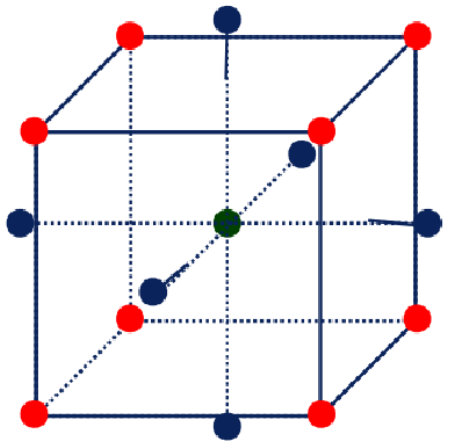

Principe : plan factoriel + points axiaux et centraux

Avantage : Prend facilement la suite d’un plan factoriel

Inconvénient : Point à l’extérieur du cube

## Le plan de Box Benkhen

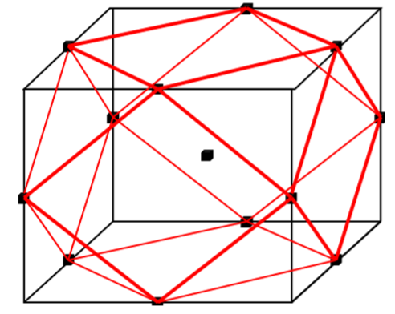

Principe : Points centraux des bords

Avantage : Moins de points que les plans composites

Inconvénient : Pas de plan factoriel imbriqué donc inapproprié pour les expériences séquentielles

## IV.2 Les plans optimisés

on a : \[\mathbb{V}(\hat{\beta}) = \sigma^{2}(^{t}{X}X)^{-1}\]

Donc \[\forall 1\leq i\leq n, \: \mathbb{V}(\beta_{i}) = \sigma^{2}(^{t}{X}X)^{-1}_{ii}\]

\(\Rightarrow\) On s’intéresse à la matrice \((^{t}{X}X)^{-1}\) (et donc à \((^{t}{X}X)\)) pour minimiser la variance.

Dans la suite, on note \(\lambda_{0}, .. , \lambda_{p}\) les valeurs propres de \((^{t}{X}X)^{-1}\).

## D-optimalité :

\((^{t}{X}X)^{-1} = \frac{1}{det(^{t}{X}X)}\times^{t}{[(^{t}{X}X)^{*}]}\)

où \((^{t}{X}X)^{*}\) désigne la matrice des cofacteurs associée à la matrice \(^{t}{X}X\).

Donc grossièrement, les éléments de \(\mathbb{V}(\hat{\beta})\) (et les diagonaux notamment) seront donc d’autant plus petits que \(det(^{t}{X}X)\) est grand.

On cherche alors la position des points \(\pi_{D}\) : \[\pi_{D} = argmax(det(^{t}{X}X)) = argmin(\lambda_{0}\times .. \times\lambda_{p})\]

## A-optimalité

On a \(\sum_{i} \mathbb{V}(\beta_{i})\:= \: \sigma^{2}\:Trace((^{t}{X}X)^{-1}))\: = \:\sigma^{2}\sum_{i} \lambda_{i}\)

On cherche alors la position des points \(\pi_{D}\) : \[\pi_{D} = argmin(Trace((^{t}{X}X)^{-1})) = argmin(\sum_{i} \lambda_{i})\]

## G-optimalité

On peut également s’intéresser directement à la variance de prédiction, en cherchant la position des points \(\pi_{D}\) telle que :

\[ \pi_{D} = argmin [\:max_{x \in \mathbb{X}}(\mathbb{V}(\hat{y}(x)))\:]\]

avec \(\mathbb{V}(\hat{y}(x)) = \sigma^2(^{t}x(^{t}XX)^{-1}x)\)

## Retour sur l’exercice

On veut construire un plan pour 1 facteur quantitatif A appartenant à \([−1,1]\). On souhaite estimer un modèle de degré 2. On choisit de réaliser 3 expériences : 1 en −1, 1 en 1, 1 en a, a ∈ \([−1,1]\). Comment choisir a pour une estimation la plus précise possible des paramètres?

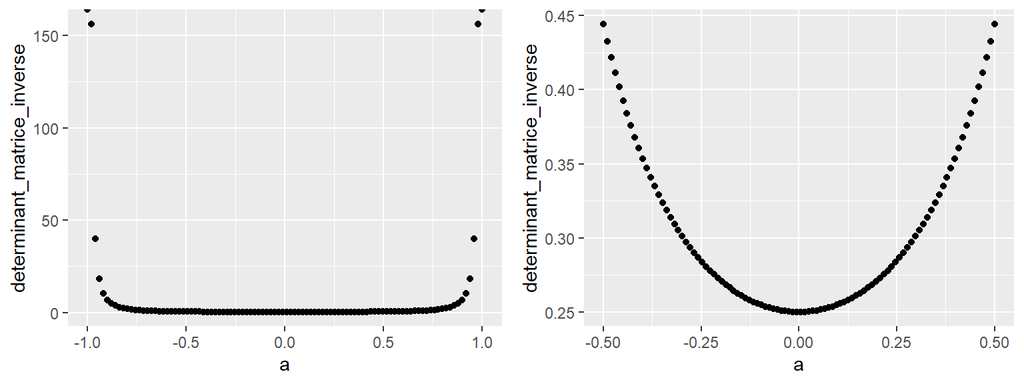